# Supplement for: Open research materials need explicit reuse licenses

Author

Affiliation

Björn S. Siepe

University of Marburg

Published

October 27, 2026

# 1 Preparation

We first load all packages and datasets and run the analysis and the manual check:

```r
library(knitr)
library(dplyr)
library(pander)
source("02_analyse_licenses.R")
# also reads the strata of the manual check (strata)
source("04_evaluate_manual_check.R")

# numbers for the method text
readme_presence <- read.csv(file.path(MAT_DIR, "osf_readme_presence.csv"))
pairs <- distinct(object_licenses, doi, osf_project)
n_shared_ids <- sum(table(pairs$osf_project) > 1)
crawl_dates <- range(object_licenses$checked)
n_components <- n_distinct(components$component_id[components$depth > 0])
n_github <- n_distinct(components$component_id[!is.na(components$github_repo)])

# pairs without a row in the deposit's documentation coding, by object type
doc_llm <- read.csv(file.path(MAT_DIR, "osf_documentation_llm.csv"))
doc_missing <- distinct(osf_files, doi, osf_project) |>
  anti_join(doc_llm, by = c("doi", "osf_project")) |>
  left_join(distinct(object_licenses, osf_project, holder_type), by = "osf_project")
```

# 2 Method

## 2.1 Population and objects

We build on the results by Quintana (v1.1.0, https://doi.org/10.5281/zenodo.22805418) and use his list of and associated documentation unchanged. His results cover empirical papers published in *Cognition*, the *Journal of Experimental Social Psychology* (JESP), the *Journal of Memory and Language* (JML) and *Psychological Science* in 2015, 2020 and 2025. We use 672 empirical papers in his sample that share materials on OSF with a readable file listing (`osf_readme_presence.csv`).

The repo’s file listing (`osf_file_downloads.csv`) links 675 papers to 939 distinct OSF objects (942 paper and object pairs; 3 objects are linked by two papers). An object can be a project, a component, a registration or a single file. Files carry no license, so a link to a file is resolved to the project or registration that holds it, the same rule as in Quintana’s `collect_osf_documentation.R`. The papers of the population link 936 of these objects.

## 2.2 Data collection

We queried the OSF API for every linked object between 2026-10-20 and 2026-10-21 (`01_collect_osf_licenses.R`). Licenses are therefore read at the crawl date, not at publication. We considered five sources of a license:

1. **OSF license field.** Each project, component and registration has a license field, which OSF shows on the project page. We recorded the license of each linked object and investigated all components nested in it, at any depth (410 components). We stored only whether a copyright holder is given, not the names.
2. **LICENSE files.** File names in the deposit’s listing that contain `license` or `licence`, or that are `COPYING` or `COPYRIGHT` (alone or followed by a separator). The listing covers components at any depth and add-on storage, but for registrations only OSF storage.
3. **GitHub add-ons.** An OSF project can connect a GitHub repository as storage. For the 9 nodes with such an add-on, we recorded the license GitHub detects in the repository. GitHub’s `NOASSERTION`, a license file it cannot match, counts as a license.
4. **Descriptions.** The description of every linked object and of its direct components.
5. **READMEs.** The README files of the 143 papers whose file listing has one (names matching `readme`, `read me` or `read_me`, as in Quintana’s `analyse_osf_readme.R`). The deposit lists file names without ids, so we walked each file tree again, including components, until all listed READMEs were found. PDF and Word files were converted to text.

Descriptions and READMEs were searched for `licen[sc]`. Each text with a match was coded by hand (16 texts, see Coding schemes). The passages are other researchers’ text, so we share only the coding and a link to each page.

## 2.3 Definitions

A paper counts as **licensed** if at least one of its linked objects or their components has a license in the OSF field, if there is a LICENSE file or a licensed GitHub add-on, or if a description or README is coded as stating a license. On OSF, “No license” is an explicit choice and counts as unlicensed; “Other” is a custom license and counts as licensed. We also report the OSF license field on its own, as it is the only machine-readable source and the one shown on the project page.

A paper can carry several **license types**, e.g. CC BY for data and MIT for code. We name them according to SPDX identifiers (https://spdx.org/licenses) and count each type once per paper.

## 2.4 Analysis

We report the share of licensed papers with exact (Clopper-Pearson) 95% confidence intervals, overall, per journal and per period (`02_analyse_licenses.R`). As licenses are read at the crawl date, older papers had more time to gain a license.

We therefore only compare papers from 2025 with earlier papers: *Psychological Science* requires an open license for submissions from 2024. 2015 has few papers on OSF, so it is pooled with 2020. OSF also asks for a license when a registration is created, which raises rates independently of journal policy, so we repeat the comparison without registrations. Finally, we compare licensing between papers with and without shared code (any code file in the deposit’s listing) and between papers with and without documentation as coded by Quintana (a README, or substantive reuse guidance in the OSF description or wiki), the latter with Fisher’s exact test.

## 2.5 Manual check

To validate the crawl, `03_sample_manual_check.R` drew a stratified sample of 67 papers (10% of the population). Each paper was assigned to one of five strata (Table 1), in the order listed, so a paper falls into the first stratum that applies. Cases where the crawl is most likely to err are oversampled: the sample includes every paper in the first two strata and 15% of the papers linking a registration or a single file. The rest of the sample is split over the last two strata in proportion to their size.

```r
stratum_info <- tibble(
  stratum = c("child, file or readme only", "no license chosen", "registration or file link",
              "licensed on OSF", "unlicensed"),
  definition = c("Licensed, but not in the OSF license field of a linked object",
                 "Unlicensed, with \"No license\" chosen on OSF",
                 "Links a registration or a single file",
                 "Licensed in the OSF license field of a linked object",
                 "All other papers")
)
stratum_info |>
  left_join(count(strata, stratum, name = "papers"), by = "stratum") |>
  kable(col.names = c("Stratum", "Definition", "Sampled papers"))
```

Table 1: Strata of the manual check, in the order they are assigned, with the number of sampled papers.

| Stratum | Definition | Sampled papers |
| --- | --- | --- |
| child, file or readme only | Licensed, but not in the OSF license field of a linked object | 11 |
| no license chosen | Unlicensed, with “No license” chosen on OSF | 6 |
| registration or file link | Links a registration or a single file | 18 |
| licensed on OSF | Licensed in the OSF license field of a linked object | 6 |
| unlicensed | All other papers | 26 |

The coding sheet is in random order and does not show our coding or the stratum. Each paper was coded by opening its OSF links and looking for a license anywhere on the linked pages, including places the crawl does not cover (e.g. the wiki). `04_evaluate_manual_check.R` compares this coding with the crawl: agreement and Cohen’s kappa for the OSF license field, and per stratum how often a license is stated elsewhere.

## 2.6 Coding schemes

### 2.6.1 License mentions

Each row of `data/license_mentions.csv` is one description or README with at least one match. Re-running `01` keeps the coding and leaves new texts empty; `02` warns if any are uncoded and counts them as no license.

[output not shown]

### 2.6.2 Manual check

Each sampled paper was coded in `data/manual_check.csv` as follows.

[output not shown]

# 3 Results

## 3.1 Licensing rates

Of the 672 papers, 179 (27%) carry a license. Table 2 shows where these licenses come from. Each licensed paper is counted once, under the first source in the list that applies, so the sources add up to the licensed papers.

```r
route_n <- setNames(license_routes$n, license_routes$route)
tibble(
  source = c("OSF license field of a linked object",
             "OSF license field of a component",
             "LICENSE file",
             "GitHub add-on",
             "README",
             "Description",
             "**Licensed**",
             "**Not licensed**",
             "of which \"No license\" chosen on OSF",
             "**All papers**"),
  n = c(route_n[c("osf_object", "child_only", "license_file_only", "github_only",
                  "readme_only", "description_only")],
        sum(papers$licensed), sum(!papers$licensed), route_n[["no_license_chosen"]],
        nrow(papers))
) |>
  mutate(pct = sprintf("%.1f", 100 * n / nrow(papers))) |>
  kable(col.names = c("Source", "Papers", "%"))
```

Table 2: Source of the license, as number and percentage of all papers. Each paper is counted under the first source that applies.

| Source | Papers | % |
| --- | --- | --- |
| OSF license field of a linked object | 168 | 25.0 |
| OSF license field of a component | 3 | 0.4 |
| LICENSE file | 5 | 0.7 |
| GitHub add-on | 0 | 0.0 |
| README | 3 | 0.4 |
| Description | 0 | 0.0 |
| **Licensed** | 179 | 26.6 |
| **Not licensed** | 493 | 73.4 |
| of which “No license” chosen on OSF | 6 | 0.9 |
| **All papers** | 672 | 100.0 |

171 papers have a license in an OSF license field (of an object or a component), 9 a LICENSE file, 5 a licensed GitHub add-on, 8 a README and 0 a description that states a license.

Table 3 shows the share of licensed papers per journal and period, once for all linked objects and once without registrations.

```r
rates_for_text |>
  mutate(cell = sprintf("%d/%d, %s", n_licensed, n, text),
         journal = if_else(journal == "all", "All journals", journal),
         period = if_else(period == "all", "All years", period)) |>
  select(objects, journal, period, cell) |>
  tidyr::pivot_wider(names_from = objects, values_from = cell) |>
  kable(col.names = c("Journal", "Period", "All objects", "Without registrations"))
```

Table 3: Licensed papers / all papers, with percentage and 95% CI.

| Journal | Period | All objects | Without registrations |
| --- | --- | --- | --- |
| All journals | All years | 179/672, 27% [95% CI 23, 30] | 152/647, 23% [95% CI 20, 27] |
| All journals | 2015 & 2020 | 68/341, 20% [95% CI 16, 25] | 66/335, 20% [95% CI 16, 24] |
| All journals | 2025 | 111/331, 34% [95% CI 28, 39] | 86/312, 28% [95% CI 23, 33] |
| Cognition | 2015 & 2020 | 21/120, 18% [95% CI 11, 25] | 21/119, 18% [95% CI 11, 26] |
| Cognition | 2025 | 37/166, 22% [95% CI 16, 29] | 32/164, 20% [95% CI 14, 26] |
| Journal of Experimental Social Psychology | 2015 & 2020 | 9/61, 15% [95% CI 7, 26] | 8/61, 13% [95% CI 6, 24] |
| Journal of Experimental Social Psychology | 2025 | 15/61, 25% [95% CI 14, 37] | 11/61, 18% [95% CI 9, 30] |
| Journal of Memory and Language | 2015 & 2020 | 11/34, 32% [95% CI 17, 51] | 11/34, 32% [95% CI 17, 51] |
| Journal of Memory and Language | 2025 | 11/51, 22% [95% CI 11, 35] | 11/51, 22% [95% CI 11, 35] |
| Psychological Science | 2015 & 2020 | 27/126, 21% [95% CI 15, 30] | 26/121, 21% [95% CI 15, 30] |
| Psychological Science | 2025 | 48/53, 91% [95% CI 79, 97] | 32/36, 89% [95% CI 74, 97] |

Figure 1 shows the share of licensed papers per journal before and after 2025 (a) and the license types used (b). The SPDX identifiers are spelled out in Table 4.

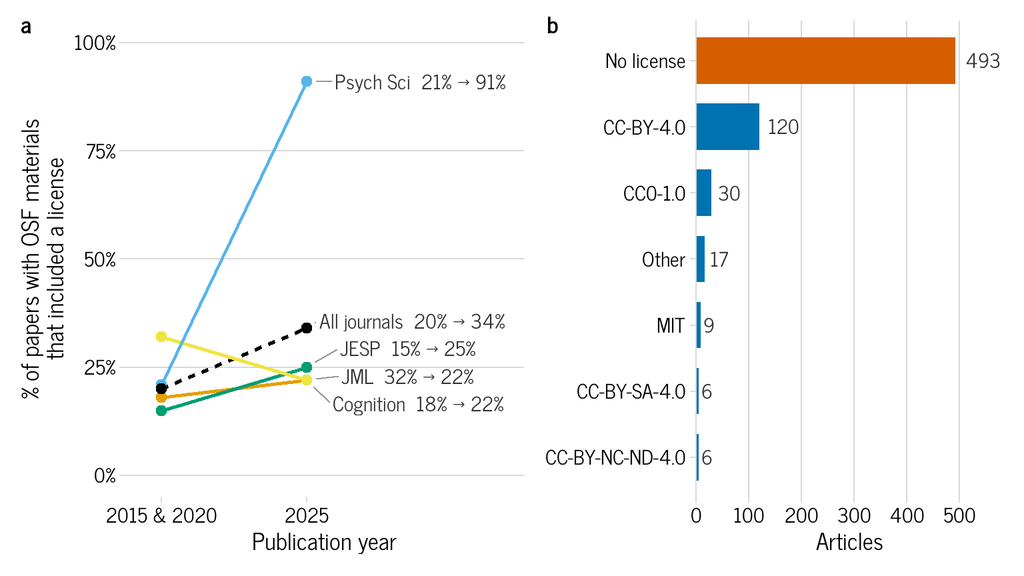

Figure 1: (a) Share of papers with OSF materials that include a license, per journal and for all journals together (dashed). (b) License types, each counted once per paper. Types used by fewer than five papers are pooled as Other. No license: papers without any license.

```r
fig
```

Figure 2 shows the same shares as panel (a) of Figure 1, one journal per panel and with 95% confidence intervals.

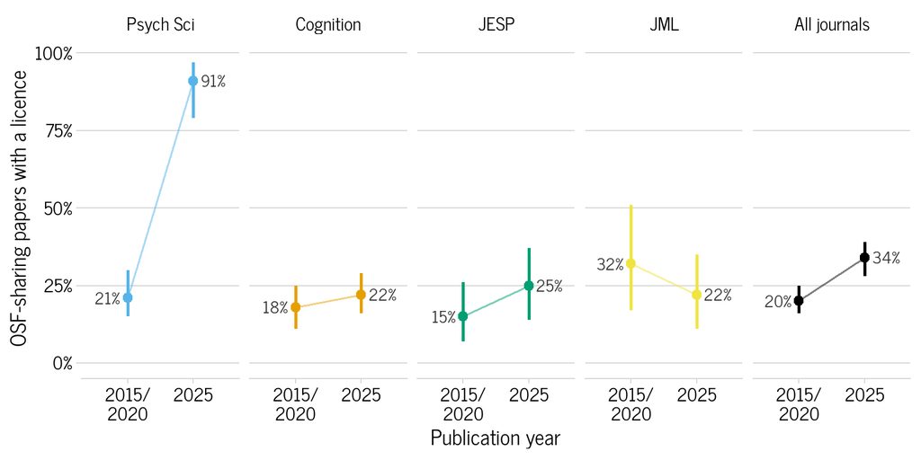

Figure 2: Share of licensed papers per journal and period, with exact 95% confidence intervals.

```r
fig_facets
```

Figure 3 shows the change between the two periods as a dumbbell chart, with the number of papers per journal and period in brackets. Panel (b) is the same as in Figure 1.

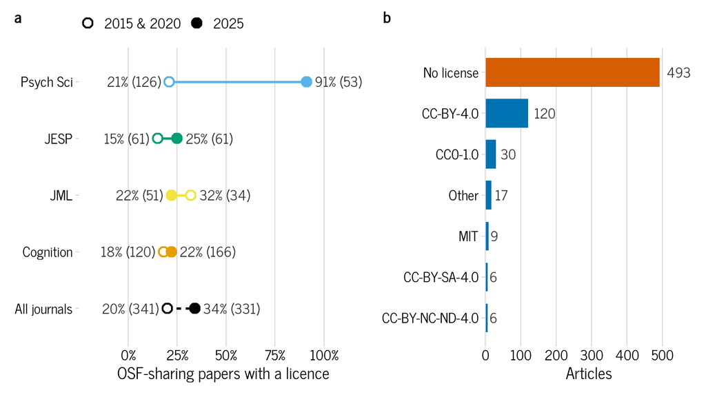

Figure 3: (a) Share of licensed papers in 2015 and 2020 (open dot) and in 2025 (filled dot), with the number of papers in brackets. (b) License types, as in Figure 1.

```r
fig_dumbbell
```

## 3.2 License types

Table 4 lists all license types. Percentages refer to all 188 uses of a license type, as a paper can carry more than one.

```r
license_counts |>
  select(short, license_name, n, pct) |>
  kable(col.names = c("SPDX id", "Name on OSF", "Papers", "% of uses"))
```

Table 4: License types, each counted once per paper.

| SPDX id | Name on OSF | Papers | % of uses |
| --- | --- | --- | --- |
| CC-BY-4.0 | CC-By Attribution 4.0 International | 120 | 64 |
| CC0-1.0 | CC0 1.0 Universal | 30 | 16 |
| MIT | MIT License | 9 | 5 |
| CC-BY-NC-ND-4.0 | CC-By Attribution-NonCommercial-NoDerivatives 4.0 International | 6 | 3 |
| CC-BY-SA-4.0 | CC-By Attribution-ShareAlike 4.0 International | 6 | 3 |
| Other | Other | 4 | 2 |
| CC-BY-NC-4.0 | CC-BY Attribution-NonCommercial 4.0 International | 3 | 2 |
| GPL-3.0 | GNU General Public License (GPL) 3.0 | 3 | 2 |
| Apache-2.0 | Apache License 2.0 | 2 | 1 |
| BSD-2-Clause | BSD 2-Clause “Simplified” License | 2 | 1 |
| LGPL-3.0 | GNU Lesser General Public License (LGPL) 3.0 | 2 | 1 |
| AFL-3.0 | Academic Free License (AFL) 3.0 | 1 | 1 |

## 3.3 Code sharing and documentation

Table 5 compares licensing between papers with and without shared code, and between papers with and without documentation. Documented papers are licensed more often (odds ratio 3.0, 95% CI 2.0 to 4.3, Fisher’s exact test).

```r
bind_rows(
  mutate(by_code, group = "Shares code", value = shares_code),
  mutate(by_doc, group = "Documented", value = documented)
) |>
  mutate(value = if_else(value, "yes", "no"),
         text = sprintf("%d%% [%d, %d]", pct, ci_low, ci_high)) |>
  select(group, value, n, n_licensed, text) |>
  kable(col.names = c("", "", "Papers", "Licensed", "% [95% CI]"))
```

Table 5: Licensed papers by code sharing and documentation, with 95% CI.

|  |  | Papers | Licensed | % [95% CI] |
| --- | --- | --- | --- | --- |
| Shares code | no | 249 | 44 | 18% [13, 23] |
| Shares code | yes | 423 | 135 | 32% [27, 37] |
| Documented | no | 472 | 94 | 20% [16, 24] |
| Documented | yes | 200 | 85 | 42% [36, 50] |

## 3.4 Manual check

Table 6 compares the OSF license field in the manual check with the crawl. The two agree for 100% of the 67 papers (Cohen’s kappa 1).

```r
agreement <- table(manual = check$manual_osf, crawl = check$ours_osf)
kable(as.data.frame.matrix(agreement), row.names = TRUE)
```

Table 6: License in the OSF field, manual check (rows) against crawl (columns).

|  | FALSE | TRUE |
| --- | --- | --- |
| FALSE | 47 | 0 |
| TRUE | 0 | 20 |

Table 7 shows per stratum how many papers are licensed by our coding and by the manual check, and how many state a license only outside the OSF field.

```r
check |>
  group_by(stratum) |>
  summarise(n = n(), licensed_ours = sum(licensed), licensed_manual = sum(manual_any),
            other_only = sum(manual_other & !manual_osf)) |>
  kable(col.names = c("Stratum", "Papers", "Licensed (crawl)", "Licensed (manual)",
                      "Only outside the OSF field"))
```

Table 7: Licensed papers per stratum, crawl and manual check.

| Stratum | Papers | Licensed (crawl) | Licensed (manual) | Only outside the OSF field |
| --- | --- | --- | --- | --- |
| child, file or readme only | 11 | 11 | 11 | 8 |
| licensed on OSF | 6 | 6 | 6 | 0 |
| no license chosen | 6 | 0 | 0 | 0 |
| registration or file link | 18 | 11 | 12 | 1 |
| unlicensed | 26 | 0 | 0 | 0 |

During our manual check, we found one paper that states a license inside a text file that links to its registration. We only looked at this file by accident, and reusers are unlikely to look for a license there. We therefore count this paper as unlicensed.

# 4 Limitations

- Licenses are read at the crawl date, not at publication; authors can add or change a license later.
- OSF asks for a license when a registration is created, and *Psychological Science* requires an open license for submissions from 2024. Both raise the 2025 rate without an author choosing a license, so rates are also reported with registrations left out.
- GitHub repositories linked in the paper or the OSF description, rather than connected as storage, are not checked. Many of them are third-party tools (e.g. PsychoPy) whose license says nothing about the shared materials.
- Some licenses were only stated in a subcomponent of the full project, leaving other parts of a project unlicensed. We count such papers as licensed, but reusers may not find the license for the part they want to use.
- Papers linking private projects through view-only links are not covered: the keys are redacted in the deposit, and those papers are outside the population.
- READMEs and descriptions are only searched for “license” or “licence”. A statement like “data: CC0” without that word is missed, as are licenses in the wiki, in files not named README, and in scanned PDFs. READMEs are read only for papers whose file listing in the deposit has one, and not all listed READMEs could be found for one registration. LICENSE files are found by name only. In the manual check, one paper stated a CC0 license inside a text file that links to the registration. We count such a paper as unlicensed, as reusers are unlikely to look for a license there.
- The comparisons with code sharing and documentation are descriptive. Licensed and documented papers may share causes, such as journal policy or the authors’ general practices.

# 5 Session info

We print the session info here, and save it to `session_info.txt`.

```r
writeLines(capture.output(sessionInfo()), "session_info.txt")
pander::pander(sessionInfo())
```

**R version 4.6.1 (2026-06-24 ucrt)**

**Platform:** x86_64-w64-mingw32/x64

**locale:** *LC_COLLATE=German_Germany.utf8*, *LC_CTYPE=German_Germany.utf8*, *LC_MONETARY=German_Germany.utf8*, *LC_NUMERIC=C* and *LC_TIME=German_Germany.utf8*

**attached base packages:** *stats*, *graphics*, *grDevices*, *datasets*, *utils*, *methods* and *base*

**other attached packages:** *psych(v.2.6.9)*, *showtext(v.0.9-8)*, *showtextdb(v.3.0)*, *sysfonts(v.0.8.9)*, *patchwork(v.1.3.2)*, *ggplot2(v.4.0.3)*, *pander(v.0.6.6)*, *dplyr(v.1.2.1)* and *knitr(v.1.52)*

**loaded via a namespace (and not attached):** *gtable(v.0.3.6)*, *jsonlite(v.2.0.0)*, *compiler(v.4.6.1)*, *renv(v.1.2.3)*, *tidyselect(v.1.2.1)*, *Rcpp(v.1.1.2)*, *parallel(v.4.6.1)*, *tidyr(v.1.3.2)*, *scales(v.1.4.0)*, *yaml(v.2.3.12)*, *fastmap(v.1.2.0)*, *lattice(v.0.22-9)*, *R6(v.2.6.1)*, *labeling(v.0.4.3)*, *generics(v.0.1.4)*, *curl(v.7.1.0)*, *forcats(v.1.0.1)*, *ggrepel(v.0.9.8)*, *tibble(v.3.3.1)*, *pillar(v.1.11.1)*, *RColorBrewer(v.1.1-3)*, *rlang(v.1.3.0)*, *utf8(v.1.2.6)*, *xfun(v.0.62)*, *S7(v.0.2.2)*, *cli(v.3.6.6)*, *withr(v.3.0.3)*, *magrittr(v.2.0.5)*, *digest(v.0.6.39)*, *grid(v.4.6.1)*, *cowplot(v.1.2.0)*, *nlme(v.3.1-169)*, *lifecycle(v.1.0.5)*, *vctrs(v.0.7.3)*, *mnormt(v.2.1.2)*, *evaluate(v.1.0.5)*, *glue(v.1.8.1)*, *farver(v.2.1.2)*, *purrr(v.1.2.2)*, *rmarkdown(v.2.32)*, *tools(v.4.6.1)*, *pkgconfig(v.2.0.3)* and *htmltools(v.0.5.9)*